# Transfer Learning with Pre-Trained Deep Neural Network Architectures – The Shallow End of Deep Learning

Ali Zaidi

2017/09/12

## Pre-Trained Models

Transfer learning is a pretty incredible method for learning expressive models without having to train a deep architecture from scratch. In some ways, it’s nearly a “free-lunch”: take a pre-built model trained for weeks on a large image corpus, and reuse the features from that model for your domain-specific task.

`MicrosoftML` ships with a number of pre-trained DNNs on the [ImageNet](http://www.image-net.org/) challenge dataset.

[output not shown]

## CMU Faces Dataset

For this notebook, we’ll use the [CMU Faces dataset](http://archive.ics.uci.edu/ml/datasets/CMU+Face+Images) compiled by Tom Mitchell and his students way back in 1999.

```r
lapply(list(train_df, test_df), dim)
```

```
[[1]]
[1] 157   2

[[2]]
[1] 155   2
```

## On-the Fly Featurization

We can develop features on-the-fly and embed them into any of the `MicrosoftML` learners. This is especially useful if we want to train on data that is too large to fit in memory, so instead we work in batches.

```r
mlTransform <- list(loadImage(vars = list(Image = "Path")),
                    resizeImage(vars = "Image",
                                width = 224, height = 224,
                                resizingOption = "IsoPad"),
                    extractPixels(vars = list(Pixels = "Image")),
                    featurizeImage(var = "Pixels", outVar = "Feature",
                                   dnnModel = "resnet101"))
model <- rxLogisticRegression(Label ~ Feature,
                              data = train_df,
                              mlTransforms = mlTransform, mlTransformVars = "Path")
```

[output not shown]

```r
summary(model)
```

```
Call:
rxLogisticRegression(formula = Label ~ Feature, data = train_df,
    mlTransforms = mlTransform, mlTransformVars = "Path")

LogisticRegression (BinaryClassifierTrainer) for: Label~Feature
Data: train_df


First 20 of 161 Non-zero Coefficients:
(Bias): 0.8676596
f2037: -0.8233218
f530: -0.7017465
f765: 0.660215
f1789: -0.6599274
f1496: -0.6279263
f483: -0.5687492
f573: 0.5668527
f164: 0.5561389
f222: 0.5508049
f396: 0.5417806
f1389: 0.5255014
f1629: 0.5162207
f425: -0.4999699
f1544: -0.4679955
f2011: 0.451557
f984: -0.4430715
f162: -0.4315767
f1395: 0.4248581
f529: 0.4129341
```

```r
score  <- rxPredict(model, test_df, extraVarsToWrite = "Label")
```

```
Beginning processing data.
Rows Read: 155, Read Time: 0.000118017, Transform Time: 3.8147e-06
Beginning processing data.
Elapsed time: 00:06:17.4361294
Finished writing 155 rows.
Writing completed.
```

```r
sum(score$Label==score$PredictedLabel)/nrow(score)
```

```
[1] 0.9612903
```

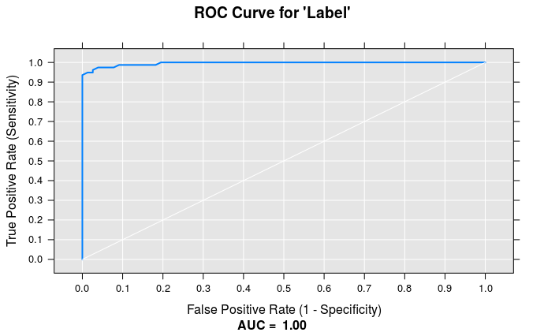

```r
rxRocCurve("Label","Probability", score)
```

## Retaining Features

While the above approach is scalable beyond datasets that can fit in memory, it has the drawback of not being reusable. In paricular, we can’t “pull-out” the features we trained on our dataset for later use.

```r
rxFeaturize(data = train_df,
            outData = "../data/train.xdf",
            overwrite = TRUE,
            mlTransforms = list(loadImage(vars = list(Image = "Path")),
                                resizeImage(vars = "Image",
                                            width = 224, height = 224,
                                            resizingOption = "IsoPad"),
                                extractPixels(vars = list(Pixels = "Image")),
                                featurizeImage(var = "Pixels",
                                               outVar = "Feature",
                                               dnnModel = "resnet18")),
            mlTransformVars = c("Path", "Label")) -> train_xdf
```

```
Beginning processing data.
Rows Read: 157, Read Time: 0.000219107, Transform Time: 3.09944e-05
Beginning processing data.
Elapsed time: 00:00:25.5243818
Finished writing 157 rows.
Writing completed.
```

```r
rxFeaturize(data = test_df, outData = "../data/test.xdf", overwrite = TRUE,
            mlTransforms = list(loadImage(vars = list(Image = "Path")),
                                resizeImage(vars = "Image", width = 224, height = 224,
                                            resizingOption = "IsoPad"),
                                extractPixels(vars = list(Pixels = "Image")),
                                featurizeImage(var = "Pixels",
                                               outVar = "Feature",
                                               dnnModel = "resnet18")),
            mlTransformVars = c("Path", "Label")) -> test_xdf
```

```
Beginning processing data.
Rows Read: 155, Read Time: 0.000250816, Transform Time: 5.00679e-06
Beginning processing data.
Elapsed time: 00:00:24.7450123
Finished writing 155 rows.
Writing completed.
```

```r
varInfo <- rxGetVarInfo(train_xdf)
features <- paste("Feature", 0:511, sep=".", collapse = " + ")
form <- as.formula(paste("Label", features, sep="~"))
model <- rxLogisticRegression(formula = form, data = train_xdf)
```

[output not shown]

```r
summary(model)
```

```
Call:
rxLogisticRegression(formula = form, data = train_xdf)

LogisticRegression (BinaryClassifierTrainer) for: Label~Feature.0+Feature.1+Feature.2+Feature.3+Feature.4+Feature.5+Feature.6+Feature.7+Feature.8+Feature.9+Feature.10+Feature.11+Feature.12+Feature.13+Feature.14+Feature.15+Feature.16+Feature.17+Feature.18+Feature.19+Feature.20+Feature.21+Feature.22+F…
Data: train_xdf (RxXdfData Data Source)
File name: ../data/train.xdf


First 20 of 101 Non-zero Coefficients:
(Bias): 0.527594
Feature.487: -1.021837
Feature.456: 0.8308995
Feature.327: -0.7830223
Feature.47: -0.7825419
Feature.280: 0.7440029
Feature.460: -0.7316988
Feature.322: 0.7101995
Feature.8: 0.598595
Feature.351: 0.593134
Feature.435: -0.5591398
Feature.269: -0.550821
Feature.270: 0.5476266
Feature.233: -0.5387868
Feature.195: -0.5254369
Feature.431: 0.5244129
Feature.380: 0.5135207
Feature.367: 0.5017179
Feature.432: -0.4670863
Feature.329: -0.4447396
```

```r
score <-rxPredict(model, test_xdf, extraVarsToWrite = "Label")
```

```
Beginning read for block: 1
Rows Read: 155, Read Time: 0.105154, Transform Time: 2.86102e-06
Beginning read for block: 2
No rows remaining. Finished reading data set.
Elapsed time: 00:00:00.1721801
Finished writing 155 rows.
Writing completed.
```

```r
sum(score$Label==score$PredictedLabel)/nrow(score)
```

```
[1] 0.9483871
```

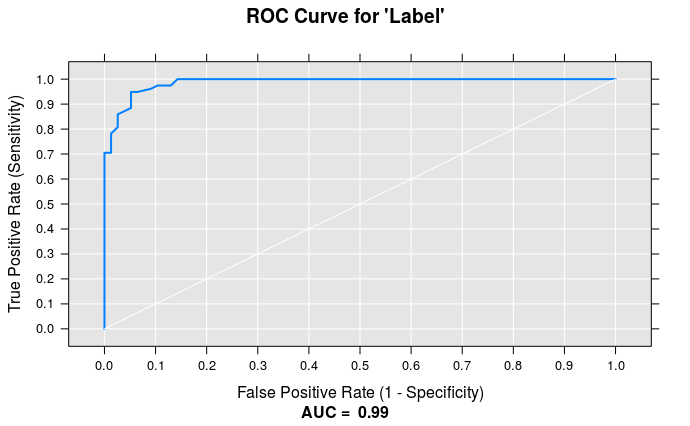

```r
rxRocCurve("Label","Probability",score)
```